# Reproducibe Research: Peer Asessment 1

cbs

Thursday, February 12, 2015

Please set working directory to the folder where activity.csv is donwloaded and would be extracted from.

Please use setwd() to set the working director and getwd() to find out the appropriate directory

Load the approrpiate packages/libraries to execute code

```r
library(ggplot2)
library(plyr)
```

Loading and preprocessing the data

```r
unzip(zipfile ="activity.zip")
activity_data <- read.csv("activity.csv", colClasses = c("integer", "Date", "integer"))
```

Transform the data into a format suitable for your analysis

```r
library(plyr)
activity_data$date <- as.Date(activity_data$date)

act_total <- ddply(activity_data, "date", summarize,
                steps = sum(steps),
                interval = sum(interval))

activity2 <- activity_data[complete.cases(activity_data),]

activity2$time <- strptime((sapply(activity2$interval, formatC, width = 4, flag = 0)), format = "%H%M")

activity2$time <- format(activity2$time, "%H:%M")

activity_sum2 <- ddply(activity2, "date", summarize,
                 steps = sum(steps),
                 interval = sum(interval),
                 time = max(time))

interval_sum2 <- ddply(activity2, "time", summarize,
                      date = mode(date),
                      steps = mean(steps),
                      interval = max(interval))
```

## What is mean total number of steps taken per day?

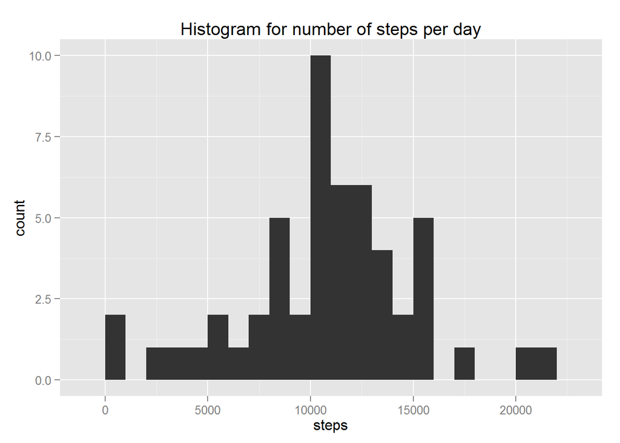

```r
library(ggplot2)
qplot(steps, data = activity_sum2, main="Histogram for number of steps per day", binwidth = 1000)
```

The mean of steps taken per day is calculated as:

```r
mean(activity_sum2$steps)
```

```
## [1] 10766.19
```

and the median for total of steps per days is:

```r
median(activity_sum2$steps)
```

```
## [1] 10765
```

## What is the average daily activity pattern?

Make a time series plot (i.e. type = “l”) of the 5-minute interval (x-axis) and the average number of steps taken, averaged across all days (y-axis)

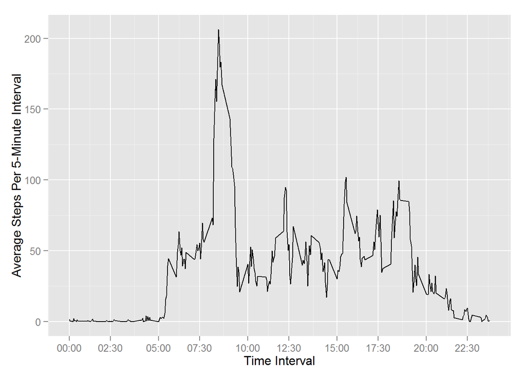

```r
qqq<-interval_sum2$time
aaa<-interval_sum2$interval
a1<-aaa[seq(1,length(aaa),30)]
q1<-qqq[seq(1,length(qqq),30)]

ggplot(data = interval_sum2, aes(interval, steps )) + geom_line() + scale_x_continuous(breaks=a1, labels=q1) + ylab("Average Steps Per 5-Minute Interval") + xlab("Time Interval")
```

Which 5-minute interval, on average across all the days in the datasets, contains the maximum number of steps?

```r
maxint <- interval_sum2$interval[which(interval_sum2$steps == max(interval_sum2$steps))]
maxtime <- interval_sum2$time[which(interval_sum2$steps == max(interval_sum2$steps))]
```

On average, across all the days in the dataset, the maximum number of steps occurs during the interval is 835 or the daily time of 08:35

Imputing missing value

```r
x <- (is.na(activity_data$steps))
numna <- sum(x)
```

Devise a strategy for filling in all of the missing in the dataset. The strategy does not need to be sophisticated. For example, you could use the mean/median for that day. or the mean for the 5 minute interval etc

I use the strategy where I impute the 5 minute interval mean

```r
stepmeans <- ddply(activity2, ~interval, summarise, mean = mean(steps))
interval <- stepmeans$interval
df <- activity_data

for(i in 1:length(df[,1])){
  if(is.na(df[i,1]))
    {df[i,1] <- stepmeans[which(interval == df[i,3]),2]}
  else if (is.na(df[i,1]) ==  FALSE)
    { df[i,1] <- df[i,1]}
  }
```

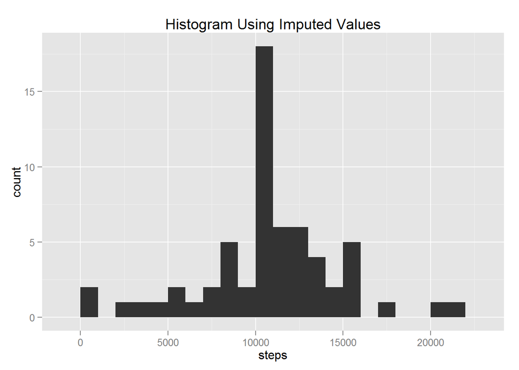

```r
df$time<-strptime((sapply(df$interval, formatC, width = 4, flag = 0)), format = "%H%M")
df$time <- format(df$time,"%H:%M")

dfsum2<-ddply(df, "date", summarize,
              steps=sum(steps),
              interval=sum(interval),
              time=max(time))

qplot(steps, data=dfsum2, main='Histogram Using Imputed Values', binwidth=1000)
```

```r
oldmean<-mean(activity_sum2$steps)
oldmedian<-median(activity_sum2$steps)

impmean<-mean(dfsum2$steps)
impmedian<-median(dfsum2$steps)
```

*Do these values differ from the estimates from the first part of the assignment? What is the impact of imputing missing data on the estimates of the total daily number of steps?*

This histogram is more centralizied, with more values landing on the average, whereas the tails are mostly not affected.

## Are there differences in activity patterns between weekdays and weekends?

For this part the weekdays() function may be of some help here. Use the dataset with the filled-in missing values for this part.

Create a new factor variable in the dataset with two levels - “weekday” and “weekend” indicating whether a given date is a weekday or weekend day.

```r
for (i in 1:length(df[, 2])){
    if (weekdays(df[i, 2])=="Saturday")
        {df$weekend[i]<-'weekend'}
    else if ((weekdays(df[i, 2])=="Sunday"))
        {df$weekend[i]<-'weekend'}
    else {df$weekend[i]<-'weekday'}
}

 dfweekend<-ddply(df,~time*weekend,summarise,
                  date=mode(date),
                  steps=format(mean(steps), scientific = NA),
                  interval=max(interval),
                  time=max(time))
```

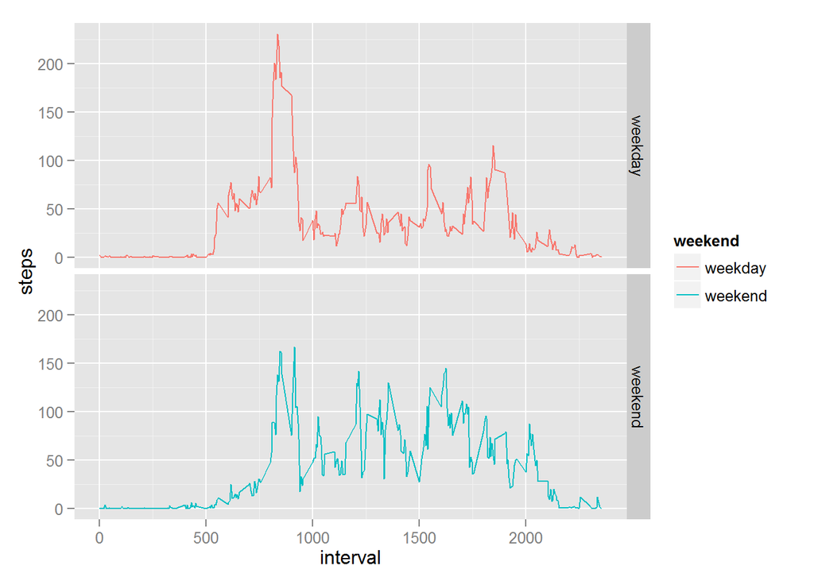

```r
library(lattice)

dfweekend <- transform(dfweekend, weekend = factor(weekend))
x<-dfweekend$interval
y<-dfweekend$steps
z<-dfweekend$weekend
dfweekend$steps<-as.numeric(dfweekend$steps)

ggplot(data=dfweekend, aes(x=interval, y=steps, color=weekend))+geom_line() + facet_grid(weekend~.)
```

Thank you for viewing the report.